# Unemployment rates by gender forecasting in Colombia

October 7th, 2020

## Overview

The International Labour Organization claims that the current global labour force participation rate for women is close to 49%. For men, it’s 75%, which represents a difference in 26 percent points.

While the gap in Colombia is 5 percent points on average, this phenomena is deepened in situations of economic uncertainty, when general unemployment increases. The main explanation is women dedicate more time in housework. Besides, it is not easy to deal with this situation in terms of public policy, since simple economic growth does not lead to a reduction in the gap.

Unemployment data is taken from the Administrative National Department of Statistics of Colombia (DANE, for its acronym in Spanish).

## Brief descriptive analysis

```r
# Load data
un_data <- as.data.table(read.xlsx("unemployment_gender.xlsx"))
un_data[, date := as.Date(date, origin = "1899-12-30")]
un_data <- un_data[year(date) == 2020]
un_data
```

```
##          date un_women    un_men
## 1: 2020-01-01 16.36123  9.830845
## 2: 2020-02-01 18.38546 11.874506
## 3: 2020-03-01 21.40999 15.225960
## 4: 2020-04-01 24.62062 17.371056
## 5: 2020-05-01 25.49342 17.009726
```

Here you see unemployment rates for both genders for the available data for 2020, where you can evidence the gap we talked about in the previous slide.

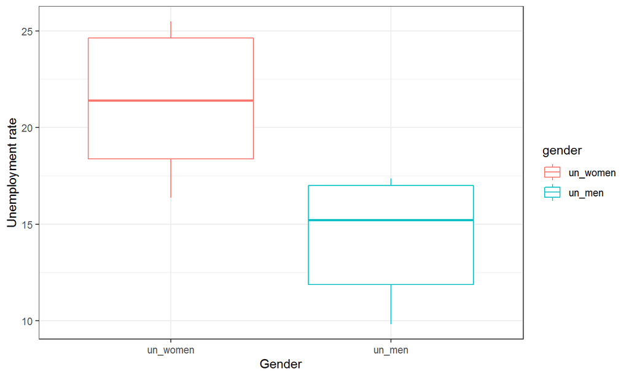

```r
ggplot(data = un_datad) +
  geom_boxplot(aes(x = gender, y = unemployment_rate, col = gender)) +
  theme_bw() +
  labs(x = "Gender", y = "Unemployment rate")
```

## Shiny App

In the following link you will be able to visualize and interact with a Shiny app that is intended to show the numeric and plot outputs from a time series model which forecasts unemployment rates by gender in Colombia, where the user has the option to choose number of months ahead to forecast and to select only one gender series plot, or both if wanted:

https://carolinart.shinyapps.io/UnemploymentForecastingGenderColombia/

Also, if you want to see the codes and more info about it, you can click here: https://github.com/carolinart/Shiny-App-Project-JHU-

Thanks for your attention!